# 01_raw_data_alignment

**Raw data alignment**

This tutorial will cover the steps for performing the alignment of raw RNA- and HiFi-sequencing data. You will need to use [the software IGV](https://software.broadinstitute.org/software/igv/download) on your computer to visualize some of the output files, which can be easily downloaded once they are produced. At the end of this tutorial you will be able to:

- perform and discuss quality control on raw data in `fastq` format using `FastQC` and `MultiQC`
- align HiFi and RNA sequencing data with dedicated tools such as `MiniMap2` and `STAR`
- analyze the quality the alignment with `qualimap` The output of this notebook will be used for the Variant calling analysis and the bulk RNA-sequencing analysis. If you do not want to run this notebook, you can alternatively use [the free interactive tool Galaxy](https://usegalaxy.org/) to perform the alignment steps. We have uploaded the data on Galaxy, and the manual to perform the exercise is found [at the course webpage](https://hds-sandbox.github.io/NGS_summer_course_Aarhus/).

The present tutorial, like the rest of the course material, is available at our [open-source github repository](https://github.com/hds-sandbox/NGS_summer_course_Aarhus).

A few introductory points to run this notebook:

- To use this notebook, use the `NGS (python)` kernel that contains the packages. Choose it by selecting `Kernel -> Change Kernel` in the menu on top of the window.

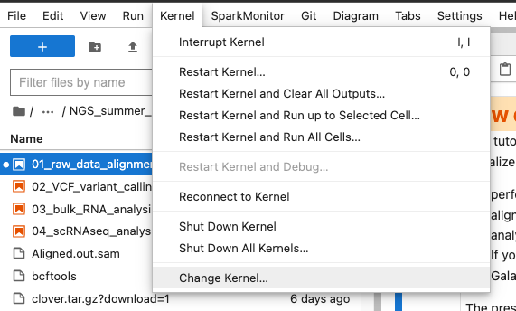

- In this notebook you will use only bash commands as you would do in the command line (this is why you read `%%bash` at the beginning of each piece of code). Those commands can be replicated in the command line, but we thought of integrating them in a notebook to make the tutorial understandable. The bash commands can also be marked with an `!` sign at the beginning of the line
- On some computers, you might see the result of the commands once they are done running. This means you will wait some time while the computer is crunching, and only afterwards you will see the result of the command you have executed
- You can run the code in each cell by clicking on the run cell button, or by pressing `Shift` + `Enter`. When the code is done running, a small green check sign will appear on the left side
- You need to run the cells in sequential order, please do not run a cell until the one above finished running and do not skip any cells
- Each cell contains a short description of the code and the output you should get. Please try not to focus on understanding the code for each command in too much detail, but rather try to focus on the output
- You can create new code cells by pressing `+` in the Menu bar above.

# Biological background

White clover (Trifolium repens) is an allotetraploid. It is a relatively young, outcrossing species, which originated during the most recent glaciation around 20,000 years ago by hybridisation of two diploid species, T. occidentale and T. pallescens (see figure below).

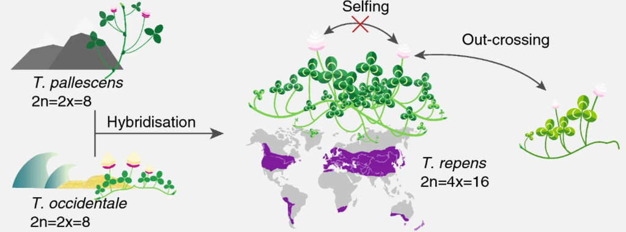

This means that it contains genomes originating from two different species within the same nucleus. Normally, white clover is an outbreeding species, but a self-compatible line was used for sequencing the white clover genome [(Griffiths et al, 2019)](https://academic.oup.com/plcell/article/31/7/1466/5985684). This line will be designated as `S10` in the data, indicating that this is the 10th self-fertilized generation. In addition, we have data from a wild clover accession (ecotype) called Tienshan (`Ti`), which is collected from the Chinese mountains and is adapted to alpine conditions.

We will perform alignment of the data to the white clover's reference genome containing both T. occidentale and T. pallescens (called `contig 1` and `contig 2` in the data). We will also perform alignment to each subgenome, and see which are the differences with the quality control tools.

Check if the data folder is there

```python
%%bash
sh ../Scripts/dataDownloadScript.sh
```

```
========================================================
Datasets folder already exists, no need to download it
========================================================
```

# Quality control and mapping

## Quality Control

```python
%%bash
#run fastqc
mkdir -p results/fastqc_output
fastqc -q -o results/fastqc_output ../Data/Clover_Data/*.fastq
```

```python
%%bash
#run multiqc
multiqc --outdir results/multiqc_output/fastqc_data results/fastqc_output
```

```
  /// MultiQC 🔍 | v1.13.dev0

|           multiqc | Search path : /usr/Intro_to_NGS/Notebooks/results/fastqc_output
|         searching | ━━━━━━━━━━━━━━━━━━━━━━━━━━━━━━━━━━━━━━━━ 100% 50/50
|            fastqc | Found 25 reports
|           multiqc | Compressing plot data
|           multiqc | Report      : results/multiqc_output/fastqc_data/multiqc_report.html
|           multiqc | Data        : results/multiqc_output/fastqc_data/multiqc_data
|           multiqc | MultiQC complete
```

**Questions**

Visualize the Webpage generated by MultiQC.

Hint: You can find a `Help` button that offers additional information about the plots for each panel. Focus on the following panels: “Per base sequence quality”, “Per sequence quality scores”.... (“Per base sequence content” always gives a `FAIL` for RNA-seq data).

- What do you notice with respect to the sequence quality scores?
- Are there any other quality issues worth noting?

## Hifi data mapping

We map the PacBio Hifi reads (`Hifi_reads_white_clover.fastq`) to the white clover reference sequence (Contig1&2) using `minimap2`. We run two mapping rounds, using two different preset options (`-x` in the command) for the technology:

- PacBio/Oxford Nanopore read to reference mapping: `map-pb`
- Long assembly to reference mapping. Divergence is far below 5%” settings `asm5`. Next, we create reports of the mapping results by running `QualiMap` on the two obtained SAM files.

We first need to index the reference fasta files using `samtools faidx`. This produces files in `.fai` format containing informations about length of the reference sequence, offset for the quality scores, name of the reference sequence. [Click here](http://www.htslib.org/doc/faidx.html) for a detailed overview.

```python
%%bash
#copy the reference data in the folder reference_data, so that you can write the indexing files
mkdir -p reference_data
cp ../Data/Clover_Data/DNA_Contig1_2.fasta ../Data/Clover_Data/DNA_Contig1.fasta ../Data/Clover_Data/DNA_Contig2.fasta reference_data
```

```python
%%bash
samtools faidx reference_data/DNA_Contig1_2.fasta
samtools faidx reference_data/DNA_Contig1.fasta
samtools faidx reference_data/DNA_Contig2.fasta
```

we create an output folder for the HIFI alignment, and run `minimap2` with the settings explained before.

```python
%%bash
mkdir -p results/HIFI_alignment/
minimap2 -a -x map-pb -o results/HIFI_alignment/PacBio_clover_alignment_1_2_mappb.sam \
                            reference_data/DNA_Contig1_2.fasta \
                            ../Data/Clover_Data/Hifi_reads_white_clover.fastq

minimap2 -a -x asm5 -o results/HIFI_alignment/PacBio_clover_alignment_1_2_asm5.sam \
                            reference_data/DNA_Contig1_2.fasta \
                            ../Data/Clover_Data/Hifi_reads_white_clover.fastq
```

```
[M::mm_idx_gen::0.069*1.05] collected minimizers
[M::mm_idx_gen::0.094*1.55] sorted minimizers
[M::main::0.094*1.55] loaded/built the index for 2 target sequence(s)
[M::mm_mapopt_update::0.106*1.48] mid_occ = 11
[M::mm_idx_stat] kmer size: 19; skip: 10; is_hpc: 1; #seq: 2
[M::mm_idx_stat::0.112*1.46] distinct minimizers: 203943 (79.05% are singletons); average occurrences: 1.273; average spacing: 8.047; total length: 2089554
[M::worker_pipeline::10.751*2.90] mapped 4395 sequences
[M::main] Version: 2.24-r1122
[M::main] CMD: minimap2 -a -x map-pb -o results/HIFI_alignment/PacBio_clover_alignment_1_2_mappb.sam reference_data/DNA_Contig1_2.fasta ../Data/Clover_Data/Hifi_reads_white_clover.fastq
[M::main] Real time: 10.762 sec; CPU: 31.157 sec; Peak RSS: 1.189 GB
[M::mm_idx_gen::0.062*1.05] collected minimizers
[M::mm_idx_gen::0.089*1.62] sorted minimizers
[M::main::0.089*1.62] loaded/built the index for 2 target sequence(s)
[M::mm_mapopt_update::0.099*1.56] mid_occ = 50
[M::mm_idx_stat] kmer size: 19; skip: 19; is_hpc: 0; #seq: 2
[M::mm_idx_stat::0.103*1.53] distinct minimizers: 165056 (78.87% are singletons); average occurrences: 1.271; average spacing: 9.959; total length: 2089554
[M::worker_pipeline::19.180*2.94] mapped 4395 sequences
[M::main] Version: 2.24-r1122
[M::main] CMD: minimap2 -a -x asm5 -o results/HIFI_alignment/PacBio_clover_alignment_1_2_asm5.sam reference_data/DNA_Contig1_2.fasta ../Data/Clover_Data/Hifi_reads_white_clover.fastq
[M::main] Real time: 19.192 sec; CPU: 56.449 sec; Peak RSS: 1.625 GB
```

`samtools sort` is used to sort the alignment with left-to-right coordinates. The output is in `.bam` format, with `.sam` files in input (Note that you could have gotten `.bam` files from `minimap2` with a specific option).

```python
%%bash
samtools sort results/HIFI_alignment/PacBio_clover_alignment_1_2_mappb.sam \
                -o results/HIFI_alignment/PacBio_clover_alignment_1_2_mappb.sort.bam

samtools sort results/HIFI_alignment/PacBio_clover_alignment_1_2_asm5.sam \
                -o results/HIFI_alignment/PacBio_clover_alignment_1_2_asm5.sort.bam
```

`samtools index` creates the index for the `bam` file, stored in `.bai` format. The index file lets programs access any position into the aligned data without reading the whole file, which would take too much time.

```python
%%bash
samtools index results/HIFI_alignment/PacBio_clover_alignment_1_2_mappb.sort.bam
samtools index results/HIFI_alignment/PacBio_clover_alignment_1_2_asm5.sort.bam
```

Run quality control on both files

```python
%%bash
qualimap bamqc -bam results/HIFI_alignment/PacBio_clover_alignment_1_2_mappb.sort.bam \
                 -outdir results/qualimap_output/PacBio_clover_alignment_1_2_mappb

qualimap bamqc -bam results/HIFI_alignment/PacBio_clover_alignment_1_2_asm5.sort.bam \
                 -outdir results/qualimap_output/PacBio_clover_alignment_1_2_asm5
```

```
Java memory size is set to 1200M
Launching application...

QualiMap v.2.2.2-dev
Built on 2019-11-11 14:05

Selected tool: bamqc
Available memory (Mb): 33
Max memory (Mb): 1258
Starting bam qc....
Loading sam header...
Loading locator...
Loading reference...
Number of windows: 400, effective number of windows: 401
Chunk of reads size: 1000
Number of threads: 8
Processed 50 out of 401 windows...
Processed 100 out of 401 windows...
Processed 150 out of 401 windows...
Processed 200 out of 401 windows...
Processed 250 out of 401 windows...
Processed 300 out of 401 windows...
Processed 350 out of 401 windows...
Processed 400 out of 401 windows...
Total processed windows:401
Number of reads: 4395
Number of valid reads: 4696
Number of correct strand reads:0

Inside of regions...
Num mapped reads: 4395
Num mapped first of pair: 0
Num mapped second of pair: 0
Num singletons: 0
Time taken to analyze reads: 11
Computing descriptors...
numberOfMappedBases: 70274383
referenceSize: 2089554
numberOfSequencedBases: 70039397
numberOfAs: 23621784
```

[output cut: 43 more lines]

```
Time taken to analyze reads: 11
Computing descriptors...
numberOfMappedBases: 69529898
referenceSize: 2089554
numberOfSequencedBases: 69465134
numberOfAs: 23430516
Computing per chromosome statistics...
Computing histograms...
Overall analysis time: 11
end of bam qc
Computing report...
Writing HTML report...
HTML report created successfully

Finished
```

Now you can visualize the reports generated by QualiMap, which can be found in the folder `results/qualimap_output`.

Next, we map the white clover PacBio Hifi reads to contig1 and contig2 separately, using the setting you selected at the previous step (let's say `map-pb` was chosen, but you are free to change this setting in the commands). As the two contigs represent the two white clover subgenomes, this mapping will allow you to see the two subgenome haplotypes and call subgenome SNPs.

```python
%%bash
minimap2 -a -x map-pb -o results/HIFI_alignment/PacBio_clover_alignment_1.sam \
                            reference_data/DNA_Contig1.fasta \
                            ../Data/Clover_Data/Hifi_reads_white_clover.fastq
```

```
[M::mm_idx_gen::0.043*1.10] collected minimizers
[M::mm_idx_gen::0.064*1.71] sorted minimizers
[M::main::0.064*1.71] loaded/built the index for 1 target sequence(s)
[M::mm_mapopt_update::0.071*1.64] mid_occ = 10
[M::mm_idx_stat] kmer size: 19; skip: 10; is_hpc: 1; #seq: 1
[M::mm_idx_stat::0.075*1.60] distinct minimizers: 112547 (91.45% are singletons); average occurrences: 1.141; average spacing: 8.031; total length: 1031631
[M::worker_pipeline::23.215*2.95] mapped 4395 sequences
[M::main] Version: 2.24-r1122
[M::main] CMD: minimap2 -a -x map-pb -o results/HIFI_alignment/PacBio_clover_alignment_1.sam reference_data/DNA_Contig1.fasta ../Data/Clover_Data/Hifi_reads_white_clover.fastq
[M::main] Real time: 23.225 sec; CPU: 68.455 sec; Peak RSS: 2.256 GB
```

```python
%%bash
minimap2 -a -x map-pb -o results/HIFI_alignment/PacBio_clover_alignment_2.sam \
                            reference_data/DNA_Contig2.fasta \
                            ../Data/Clover_Data/Hifi_reads_white_clover.fastq
```

```
[M::mm_idx_gen::0.042*1.08] collected minimizers
[M::mm_idx_gen::0.069*1.77] sorted minimizers
[M::main::0.069*1.77] loaded/built the index for 1 target sequence(s)
[M::mm_mapopt_update::0.076*1.69] mid_occ = 10
[M::mm_idx_stat] kmer size: 19; skip: 10; is_hpc: 1; #seq: 1
[M::mm_idx_stat::0.081*1.65] distinct minimizers: 120722 (93.18% are singletons); average occurrences: 1.087; average spacing: 8.062; total length: 1057923
[M::worker_pipeline::23.681*2.95] mapped 4395 sequences
[M::main] Version: 2.24-r1122
[M::main] CMD: minimap2 -a -x map-pb -o results/HIFI_alignment/PacBio_clover_alignment_2.sam reference_data/DNA_Contig2.fasta ../Data/Clover_Data/Hifi_reads_white_clover.fastq
[M::main] Real time: 23.693 sec; CPU: 69.834 sec; Peak RSS: 2.056 GB
```

Sort the bam files and create their index using `samtools`

```python
%%bash
samtools sort results/HIFI_alignment/PacBio_clover_alignment_1.sam -o results/HIFI_alignment/PacBio_clover_alignment_1.sort.bam
samtools sort results/HIFI_alignment/PacBio_clover_alignment_2.sam -o results/HIFI_alignment/PacBio_clover_alignment_2.sort.bam
```

```python
%%bash
samtools index results/HIFI_alignment/PacBio_clover_alignment_1.sort.bam
samtools index results/HIFI_alignment/PacBio_clover_alignment_2.sort.bam
```

Perform quality control

```python
%%bash
mkdir -p results/qualimap_output
qualimap bamqc -bam results/HIFI_alignment/PacBio_clover_alignment_1.sort.bam -outdir results/qualimap_output/PacBio_clover_alignment_1
```

```
Java memory size is set to 1200M
Launching application...

QualiMap v.2.2.2-dev
Built on 2019-11-11 14:05

Selected tool: bamqc
Available memory (Mb): 33
Max memory (Mb): 1258
Starting bam qc....
Loading sam header...
Loading locator...
Loading reference...
Number of windows: 400, effective number of windows: 400
Chunk of reads size: 1000
Number of threads: 8
Processed 50 out of 400 windows...
Processed 100 out of 400 windows...
Processed 150 out of 400 windows...
Processed 200 out of 400 windows...
Processed 250 out of 400 windows...
Processed 300 out of 400 windows...
Processed 350 out of 400 windows...
Processed 400 out of 400 windows...
Total processed windows:400
Number of reads: 4395
Number of valid reads: 9070
Number of correct strand reads:0

Inside of regions...
Num mapped reads: 4356
Num mapped first of pair: 0
Num mapped second of pair: 0
Num singletons: 0
Time taken to analyze reads: 11
Computing descriptors...
numberOfMappedBases: 59058058
referenceSize: 1031631
numberOfSequencedBases: 54917933
numberOfAs: 18508479
Computing per chromosome statistics...
Computing histograms...
Overall analysis time: 11
end of bam qc
Computing report...
Writing HTML report...
HTML report created successfully

Finished
```

```python
%%bash
qualimap bamqc -bam results/HIFI_alignment/PacBio_clover_alignment_2.sort.bam -outdir results/qualimap_output/PacBio_clover_alignment_2
```

```
Java memory size is set to 1200M
Launching application...

QualiMap v.2.2.2-dev
Built on 2019-11-11 14:05

Selected tool: bamqc
Available memory (Mb): 33
Max memory (Mb): 1258
Starting bam qc....
Loading sam header...
Loading locator...
Loading reference...
Number of windows: 400, effective number of windows: 400
Chunk of reads size: 1000
Number of threads: 8
Processed 50 out of 400 windows...
Processed 100 out of 400 windows...
Processed 150 out of 400 windows...
Processed 200 out of 400 windows...
Processed 250 out of 400 windows...
Processed 300 out of 400 windows...
Processed 350 out of 400 windows...
Processed 400 out of 400 windows...
Total processed windows:400
Number of reads: 4395
Number of valid reads: 9462
Number of correct strand reads:0

Inside of regions...
Num mapped reads: 4394
Num mapped first of pair: 0
Num mapped second of pair: 0
Num singletons: 0
Time taken to analyze reads: 11
Computing descriptors...
numberOfMappedBases: 59388453
referenceSize: 1057923
numberOfSequencedBases: 55867300
numberOfAs: 18822184
Computing per chromosome statistics...
Computing histograms...
Overall analysis time: 11
end of bam qc
Computing report...
Writing HTML report...
HTML report created successfully

Finished
```

**Task: IGV visualization and Questions**

Now you can inspect the alignment files in `IGV`.

- First, you will need to download the reference fasta sequence in `../Data/Clover_Data/DNA_Contig1_2.fasta` and import it into IGV. You can do the same for the files `DNA_Contig1.fasta` and `DNA_Contig2.fasta` that you might need later. In IGV, this is done with the menu `Genomes --> Load Genome from file` menu and by selecting the relevant fasta file. Then, choose the reference you need from the drop-down menu (see figure below).

[figure not shown]

  You will not yet see much, but you can choose one of the two subgenomes (contig 1 or 2) and double click on a chromosome position to inspect the reference sequence. The next step will visualize the mapped files on IGV.
- Each mapped genome can be seen in IGV against the reference file of choice. To load an aligned file, first download it together with the index file in `.bai` format. For example, you need to download both `results/HIFI_alignment/PacBio_clover_alignment_1.sort.bam` and `results/HIFI_alignment/PacBio_clover_alignment_1.sort.bam.bai` to see this alignment (you need to open only the `.bam` file with IGV). If you open more files, their alignments will be distributed in the IGV interface, and you can change the size of each visualization yourself (below shown with only one opened alignment).

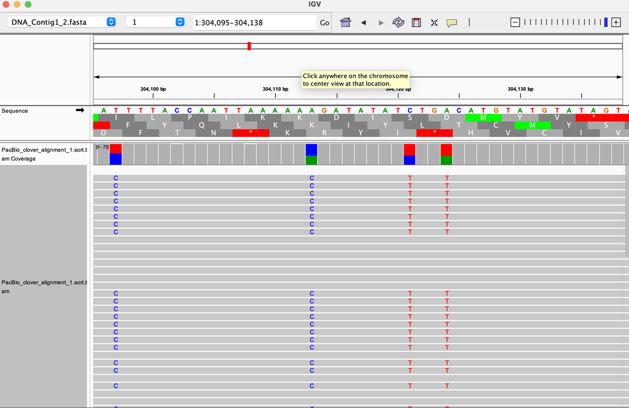

Now compare in IGV the two bam files `PacBio_clover_alignment_1.sort.bam` and `PacBio_clover_alignment_2.sort.bam`.

- What do you observe when comparing the two BAM files?
- Have a look at the polymorphic regions in IGV. Are they true polymorphisms?

- Why do you see fluctuations in coverage and large regions without any apparent subgenome SNPs?
- What are the major differences between the stats for the reads mapped to Contigs1&2 versus contig1 and contig2? What is your interpretation of the differences?

# RNA-seq mapping

First, we need to create a genome file for the reference fasta file of contigs `1` and `2`. This is done with `STAR`, using the option `--runMode genomeGenerate`. We also need to convert the gene annotation from `gff` to `gtf` format with `gffread` to allow counting gene transcripts. `STAR` is a very complex tool with many options, so it is always useful to [have a reference manual](https://physiology.med.cornell.edu/faculty/skrabanek/lab/angsd/lecture_notes/STARmanual.pdf).

```python
%%bash
gffread -T -o reference_data/white_clover_genes.gtf ../Data/Clover_Data/white_clover_genes.gff
```

```python
%%bash
STAR --runThreadN 8 \
--runMode genomeGenerate \
--genomeDir results/STAR_output/indexing_contigs_1_2 \
--genomeFastaFiles reference_data/DNA_Contig1_2.fasta \
--sjdbGTFfile reference_data/white_clover_genes.gtf
```

```
	STAR --runThreadN 8 --runMode genomeGenerate --genomeDir results/STAR_output/indexing_contigs_1_2 --genomeFastaFiles reference_data/DNA_Contig1_2.fasta --sjdbGTFfile reference_data/white_clover_genes.gtf
	STAR version: 2.7.10a   compiled: 2022-01-14T18:50:00-05:00 :/home/dobin/data/STAR/STARcode/STAR.master/source
Sep 08 09:20:35 ..... started STAR run
Sep 08 09:20:35 ... starting to generate Genome files
Sep 08 09:20:35 ..... processing annotations GTF
```

```
!!!!! WARNING: --genomeSAindexNbases 14 is too large for the genome size=2089554, which may cause seg-fault at the mapping step. Re-run genome generation with recommended --genomeSAindexNbases 9
```

```
Sep 08 09:20:35 ... starting to sort Suffix Array. This may take a long time...
Sep 08 09:20:35 ... sorting Suffix Array chunks and saving them to disk...
Sep 08 09:20:36 ... loading chunks from disk, packing SA...
Sep 08 09:20:36 ... finished generating suffix array
Sep 08 09:20:36 ... generating Suffix Array index
Sep 08 09:20:38 ... completed Suffix Array index
Sep 08 09:20:38 ..... inserting junctions into the genome indices
Sep 08 09:20:44 ... writing Genome to disk ...
Sep 08 09:20:44 ... writing Suffix Array to disk ...
Sep 08 09:20:44 ... writing SAindex to disk
Sep 08 09:20:45 ..... finished successfully
```

We got a warning saying

```
!!!!! WARNING: --genomeSAindexNbases 14 is too large for the genome size=2089554, which may cause seg-fault at the mapping step. Re-run genome generation with recommended --genomeSAindexNbases 9
```

meaning we need shorter strings of bases (9 bases instead of 14) to be indexed, as our reference genome is very short, and too long strings would cause many alignment errors. So we rerun the command with the suggested option.

```python
%%bash
STAR --runThreadN 8 \
--runMode genomeGenerate \
--genomeDir results/STAR_output/indexing_contigs_1_2 \
--genomeFastaFiles reference_data/DNA_Contig1_2.fasta \
--sjdbGTFfile reference_data/white_clover_genes.gtf \
--genomeSAindexNbases 9
```

```
	STAR --runThreadN 8 --runMode genomeGenerate --genomeDir results/STAR_output/indexing_contigs_1_2 --genomeFastaFiles reference_data/DNA_Contig1_2.fasta --sjdbGTFfile reference_data/white_clover_genes.gtf --genomeSAindexNbases 9
	STAR version: 2.7.10a   compiled: 2022-01-14T18:50:00-05:00 :/home/dobin/data/STAR/STARcode/STAR.master/source
Sep 08 09:21:21 ..... started STAR run
Sep 08 09:21:21 ... starting to generate Genome files
Sep 08 09:21:21 ..... processing annotations GTF
Sep 08 09:21:21 ... starting to sort Suffix Array. This may take a long time...
Sep 08 09:21:21 ... sorting Suffix Array chunks and saving them to disk...
Sep 08 09:21:21 ... loading chunks from disk, packing SA...
Sep 08 09:21:21 ... finished generating suffix array
Sep 08 09:21:21 ... generating Suffix Array index
Sep 08 09:21:21 ... completed Suffix Array index
Sep 08 09:21:21 ..... inserting junctions into the genome indices
Sep 08 09:21:22 ... writing Genome to disk ...
Sep 08 09:21:22 ... writing Suffix Array to disk ...
Sep 08 09:21:22 ... writing SAindex to disk
Sep 08 09:21:22 ..... finished successfully
```

We use again `STAR` to align every single library for `S10`. We extract the library name of each file and run STAR through each pair of files. Note that plant introns are very rarely more than `5000 bp` and that you are mapping to two homoeologous contigs that show high similarity, especially in genic regions. We set the maximum size to 5000 using `--alignIntronMax 5000`.

```python
%%bash
for i in `ls ../Data/Clover_Data/S10*.R1.fastq`
do

PREFIXNAME=`basename $i .R1.fastq`
echo "###############################################"
echo "##### ALIGNING PAIRED-END READS "$PREFIXNAME
echo "###############################################"
STAR --genomeDir results/STAR_output/indexing_contigs_1_2/ \
--runThreadN 8 \
--runMode alignReads \
--readFilesIn ../Data/Clover_Data/$PREFIXNAME.R1.fastq ../Data/Clover_Data/$PREFIXNAME.R2.fastq \
--outFileNamePrefix results/STAR_output/S10_align_contigs_1_2/$PREFIXNAME \
--outSAMtype BAM SortedByCoordinate \
--outSAMattributes Standard \
--quantMode GeneCounts \
--alignIntronMax 5000

done
```

```
###############################################
##### ALIGNING PAIRED-END READS S10_1_1
###############################################
	STAR --genomeDir results/STAR_output/indexing_contigs_1_2/ --runThreadN 8 --runMode alignReads --readFilesIn ../Data/Clover_Data/S10_1_1.R1.fastq ../Data/Clover_Data/S10_1_1.R2.fastq --outFileNamePrefix results/STAR_output/S10_align_contigs_1_2/S10_1_1 --outSAMtype BAM SortedByCoordinate --outSAMat…
	STAR version: 2.7.10a   compiled: 2022-01-14T18:50:00-05:00 :/home/dobin/data/STAR/STARcode/STAR.master/source
Sep 08 09:21:30 ..... started STAR run
Sep 08 09:21:30 ..... loading genome
Sep 08 09:21:30 ..... started mapping
Sep 08 09:21:38 ..... finished mapping
Sep 08 09:21:38 ..... started sorting BAM
Sep 08 09:21:38 ..... finished successfully
###############################################
##### ALIGNING PAIRED-END READS S10_1_2
###############################################
	STAR --genomeDir results/STAR_output/indexing_contigs_1_2/ --runThreadN 8 --runMode alignReads --readFilesIn ../Data/Clover_Data/S10_1_2.R1.fastq ../Data/Clover_Data/S10_1_2.R2.fastq --outFileNamePrefix results/STAR_output/S10_align_contigs_1_2/S10_1_2 --outSAMtype BAM SortedByCoordinate --outSAMat…
	STAR version: 2.7.10a   compiled: 2022-01-14T18:50:00-05:00 :/home/dobin/data/STAR/STARcode/STAR.master/source
Sep 08 09:21:39 ..... started STAR run
Sep 08 09:21:39 ..... loading genome
Sep 08 09:21:39 ..... started mapping
Sep 08 09:21:46 ..... finished mapping
Sep 08 09:21:46 ..... started sorting BAM
Sep 08 09:21:47 ..... finished successfully
###############################################
##### ALIGNING PAIRED-END READS S10_1_3
###############################################
	STAR --genomeDir results/STAR_output/indexing_contigs_1_2/ --runThreadN 8 --runMode alignReads --readFilesIn ../Data/Clover_Data/S10_1_3.R1.fastq ../Data/Clover_Data/S10_1_3.R2.fastq --outFileNamePrefix results/STAR_output/S10_align_contigs_1_2/S10_1_3 --outSAMtype BAM SortedByCoordinate --outSAMat…
	STAR version: 2.7.10a   compiled: 2022-01-14T18:50:00-05:00 :/home/dobin/data/STAR/STARcode/STAR.master/source
Sep 08 09:21:47 ..... started STAR run
Sep 08 09:21:47 ..... loading genome
Sep 08 09:21:47 ..... started mapping
Sep 08 09:21:55 ..... finished mapping
Sep 08 09:21:55 ..... started sorting BAM
Sep 08 09:21:56 ..... finished successfully
###############################################
##### ALIGNING PAIRED-END READS S10_2_1
###############################################
	STAR --genomeDir results/STAR_output/indexing_contigs_1_2/ --runThreadN 8 --runMode alignReads --readFilesIn ../Data/Clover_Data/S10_2_1.R1.fastq ../Data/Clover_Data/S10_2_1.R2.fastq --outFileNamePrefix results/STAR_output/S10_align_contigs_1_2/S10_2_1 --outSAMtype BAM SortedByCoordinate --outSAMat…
	STAR version: 2.7.10a   compiled: 2022-01-14T18:50:00-05:00 :/home/dobin/data/STAR/STARcode/STAR.master/source
Sep 08 09:21:56 ..... started STAR run
Sep 08 09:21:56 ..... loading genome
```

[output cut: 11 more lines]

```
Sep 08 09:22:04 ..... started mapping
Sep 08 09:22:11 ..... finished mapping
Sep 08 09:22:11 ..... started sorting BAM
Sep 08 09:22:12 ..... finished successfully
###############################################
##### ALIGNING PAIRED-END READS S10_2_3
###############################################
	STAR --genomeDir results/STAR_output/indexing_contigs_1_2/ --runThreadN 8 --runMode alignReads --readFilesIn ../Data/Clover_Data/S10_2_3.R1.fastq ../Data/Clover_Data/S10_2_3.R2.fastq --outFileNamePrefix results/STAR_output/S10_align_contigs_1_2/S10_2_3 --outSAMtype BAM SortedByCoordinate --outSAMat…
	STAR version: 2.7.10a   compiled: 2022-01-14T18:50:00-05:00 :/home/dobin/data/STAR/STARcode/STAR.master/source
Sep 08 09:22:12 ..... started STAR run
Sep 08 09:22:12 ..... loading genome
Sep 08 09:22:12 ..... started mapping
Sep 08 09:22:20 ..... finished mapping
Sep 08 09:22:20 ..... started sorting BAM
Sep 08 09:22:20 ..... finished successfully
```

Do the same alignment for `Tienshan` libraries

```python
%%bash
for i in `ls ../Data/Clover_Data/TI*.R1.fastq`
do

PREFIXNAME=`basename $i .R1.fastq`
echo "###############################################"
echo "##### ALIGNING PAIRED-END READS "$PREFIXNAME
echo "###############################################"
STAR --genomeDir results/STAR_output/indexing_contigs_1_2/ \
--runThreadN 8 \
--readFilesIn ../Data/Clover_Data/$PREFIXNAME.R1.fastq ../Data/Clover_Data/$PREFIXNAME.R2.fastq \
--outFileNamePrefix results/STAR_output/TI_align_contigs_1_2/$PREFIXNAME \
--outSAMtype BAM SortedByCoordinate \
--outSAMattributes Standard \
--quantMode GeneCounts \
--alignIntronMax 5000

done
```

```
###############################################
##### ALIGNING PAIRED-END READS TI_1_1
###############################################
	STAR --genomeDir results/STAR_output/indexing_contigs_1_2/ --runThreadN 8 --readFilesIn ../Data/Clover_Data/TI_1_1.R1.fastq ../Data/Clover_Data/TI_1_1.R2.fastq --outFileNamePrefix results/STAR_output/TI_align_contigs_1_2/TI_1_1 --outSAMtype BAM SortedByCoordinate --outSAMattributes Standard --quant…
	STAR version: 2.7.10a   compiled: 2022-01-14T18:50:00-05:00 :/home/dobin/data/STAR/STARcode/STAR.master/source
Sep 08 09:23:17 ..... started STAR run
Sep 08 09:23:17 ..... loading genome
Sep 08 09:23:17 ..... started mapping
Sep 08 09:23:26 ..... finished mapping
Sep 08 09:23:26 ..... started sorting BAM
Sep 08 09:23:27 ..... finished successfully
###############################################
##### ALIGNING PAIRED-END READS TI_1_2
###############################################
	STAR --genomeDir results/STAR_output/indexing_contigs_1_2/ --runThreadN 8 --readFilesIn ../Data/Clover_Data/TI_1_2.R1.fastq ../Data/Clover_Data/TI_1_2.R2.fastq --outFileNamePrefix results/STAR_output/TI_align_contigs_1_2/TI_1_2 --outSAMtype BAM SortedByCoordinate --outSAMattributes Standard --quant…
	STAR version: 2.7.10a   compiled: 2022-01-14T18:50:00-05:00 :/home/dobin/data/STAR/STARcode/STAR.master/source
Sep 08 09:23:27 ..... started STAR run
Sep 08 09:23:27 ..... loading genome
Sep 08 09:23:27 ..... started mapping
Sep 08 09:23:36 ..... finished mapping
Sep 08 09:23:36 ..... started sorting BAM
Sep 08 09:23:36 ..... finished successfully
###############################################
##### ALIGNING PAIRED-END READS TI_1_3
###############################################
	STAR --genomeDir results/STAR_output/indexing_contigs_1_2/ --runThreadN 8 --readFilesIn ../Data/Clover_Data/TI_1_3.R1.fastq ../Data/Clover_Data/TI_1_3.R2.fastq --outFileNamePrefix results/STAR_output/TI_align_contigs_1_2/TI_1_3 --outSAMtype BAM SortedByCoordinate --outSAMattributes Standard --quant…
	STAR version: 2.7.10a   compiled: 2022-01-14T18:50:00-05:00 :/home/dobin/data/STAR/STARcode/STAR.master/source
Sep 08 09:23:36 ..... started STAR run
Sep 08 09:23:36 ..... loading genome
Sep 08 09:23:36 ..... started mapping
Sep 08 09:23:46 ..... finished mapping
Sep 08 09:23:46 ..... started sorting BAM
Sep 08 09:23:47 ..... finished successfully
###############################################
##### ALIGNING PAIRED-END READS TI_2_1
###############################################
	STAR --genomeDir results/STAR_output/indexing_contigs_1_2/ --runThreadN 8 --readFilesIn ../Data/Clover_Data/TI_2_1.R1.fastq ../Data/Clover_Data/TI_2_1.R2.fastq --outFileNamePrefix results/STAR_output/TI_align_contigs_1_2/TI_2_1 --outSAMtype BAM SortedByCoordinate --outSAMattributes Standard --quant…
	STAR version: 2.7.10a   compiled: 2022-01-14T18:50:00-05:00 :/home/dobin/data/STAR/STARcode/STAR.master/source
Sep 08 09:23:47 ..... started STAR run
Sep 08 09:23:47 ..... loading genome
```

[output cut: 11 more lines]

```
Sep 08 09:23:58 ..... started mapping
Sep 08 09:24:08 ..... finished mapping
Sep 08 09:24:08 ..... started sorting BAM
Sep 08 09:24:09 ..... finished successfully
###############################################
##### ALIGNING PAIRED-END READS TI_2_3
###############################################
	STAR --genomeDir results/STAR_output/indexing_contigs_1_2/ --runThreadN 8 --readFilesIn ../Data/Clover_Data/TI_2_3.R1.fastq ../Data/Clover_Data/TI_2_3.R2.fastq --outFileNamePrefix results/STAR_output/TI_align_contigs_1_2/TI_2_3 --outSAMtype BAM SortedByCoordinate --outSAMattributes Standard --quant…
	STAR version: 2.7.10a   compiled: 2022-01-14T18:50:00-05:00 :/home/dobin/data/STAR/STARcode/STAR.master/source
Sep 08 09:24:09 ..... started STAR run
Sep 08 09:24:09 ..... loading genome
Sep 08 09:24:09 ..... started mapping
Sep 08 09:24:20 ..... finished mapping
Sep 08 09:24:20 ..... started sorting BAM
Sep 08 09:24:21 ..... finished successfully
```

Run quality control on each aligned library with `MultiQC`. In this way there will be a whole report to compare `S10` files and `Tienshan` files.

```python
%%bash
multiqc --outdir results/multiqc_output/TI_STAR_align_1_2 \
            results/STAR_output/TI_align_contigs_1_2/
```

```
  /// MultiQC 🔍 | v1.13.dev0

|           multiqc | Search path : /usr/Intro_to_NGS/Notebooks/results/STAR_output/TI_align_contigs_1_2
|         searching | ━━━━━━━━━━━━━━━━━━━━━━━━━━━━━━━━━━━━━━━━ 100% 36/36
|              star | Found 6 reports and 6 gene count files
|           multiqc | Compressing plot data
|           multiqc | Report      : results/multiqc_output/TI_STAR_align_1_2/multiqc_report.html
|           multiqc | Data        : results/multiqc_output/TI_STAR_align_1_2/multiqc_data
|           multiqc | MultiQC complete
```

```python
%%bash
multiqc --outdir results/multiqc_output/S10_STAR_align_1_2 \
            results/STAR_output/S10_align_contigs_1_2/
```

```
  /// MultiQC 🔍 | v1.13.dev0

|           multiqc | Search path : /usr/Intro_to_NGS/Notebooks/results/STAR_output/S10_align_contigs_1_2
|         searching | ━━━━━━━━━━━━━━━━━━━━━━━━━━━━━━━━━━━━━━━━ 100% 36/36
|              star | Found 6 reports and 6 gene count files
|           multiqc | Compressing plot data
|           multiqc | Report      : results/multiqc_output/S10_STAR_align_1_2/multiqc_report.html
|           multiqc | Data        : results/multiqc_output/S10_STAR_align_1_2/multiqc_data
|           multiqc | MultiQC complete
```

We merge the outputs of each group of aligned libraries. Here is how the files look like for the `Tienshan`.

```python
!ls -lh  results/STAR_output/TI_align_contigs_1_2/TI_*.sortedByCoord.out.bam
```

```
-rw-r--r--. 1 ucloud users 6.6M Sep  8 09:23 results/STAR_output/TI_align_contigs_1_2/TI_1_1Aligned.sortedByCoord.out.bam
-rw-r--r--. 1 ucloud users 6.0M Sep  8 09:23 results/STAR_output/TI_align_contigs_1_2/TI_1_2Aligned.sortedByCoord.out.bam
-rw-r--r--. 1 ucloud users 7.1M Sep  8 09:23 results/STAR_output/TI_align_contigs_1_2/TI_1_3Aligned.sortedByCoord.out.bam
-rw-r--r--. 1 ucloud users 9.6M Sep  8 09:23 results/STAR_output/TI_align_contigs_1_2/TI_2_1Aligned.sortedByCoord.out.bam
-rw-r--r--. 1 ucloud users 7.2M Sep  8 09:24 results/STAR_output/TI_align_contigs_1_2/TI_2_2Aligned.sortedByCoord.out.bam
-rw-r--r--. 1 ucloud users 8.2M Sep  8 09:24 results/STAR_output/TI_align_contigs_1_2/TI_2_3Aligned.sortedByCoord.out.bam
```

Apply `samtools merge`

```python
%%bash
mkdir -p results/STAR_output/TI_align_contigs_1_2_merge/
samtools merge -fo results/STAR_output/TI_align_contigs_1_2_merge/TI.sorted.bam results/STAR_output/TI_align_contigs_1_2/TI_*.sortedByCoord.out.bam
```

```python
%%bash
mkdir -p results/STAR_output/S10_align_contigs_1_2_merge/
samtools merge -fo results/STAR_output/S10_align_contigs_1_2_merge/S10.sorted.bam results/STAR_output/S10_align_contigs_1_2/S10_*.sortedByCoord.out.bam
```

Index both merging outputs. A file in format `bam.bai` will appear in their respective folders.

```python
%%bash
samtools index results/STAR_output/S10_align_contigs_1_2_merge/S10.sorted.bam
```

```python
%%bash
samtools index results/STAR_output/TI_align_contigs_1_2_merge/TI.sorted.bam
```

# Wrapping up 🎉 🎉 🎉